# estimating group/multi-membership models with lme4

Ben Bolker

07 April 2023

Consider a situation where we have multiple items of some sort which have associated effects, but we can’t association observations with single items; instead, each observation is associated with a *group* of items. (Two examples which have come up are (1) authorship of papers and (2) hockey players on a team.) These are *not* quite identical to “multi-membership models” (I think), although similar techniques to those shown here could work for multi-membership models.

Load packages (we don’t really need anything beyond `lme4`; the rest are for convenience/drawing pictures).

```r
library(lme4)
library(broom.mixed)
library(ggplot2); theme_set(theme_bw())
library(Matrix)
library(dplyr); library(tidyr)
```

Construct a simulated example: first, simulate the design (structure).

```r
nm <- 20
nobs0 <- 500
set.seed(101)
## choose items for observations
W1 <- matrix(rbinom(nobs0*nm, prob=0.25, size=1),nrow=nobs0,ncol=nm)
dimnames(W1) <- list(NULL,LETTERS[seq(nm)])
W1[1:5,]
```

```
##      A B C D E F G H I J K L M N O P Q R S T
## [1,] 0 0 0 0 0 1 0 0 1 1 0 0 0 0 0 0 0 0 0 0
## [2,] 0 0 0 1 1 0 0 0 0 0 0 0 0 0 0 0 0 0 0 0
## [3,] 0 0 0 0 0 1 0 1 0 0 0 0 0 0 0 0 0 1 0 0
## [4,] 0 0 0 0 0 0 0 0 0 0 0 1 0 0 0 0 0 0 1 0
## [5,] 0 1 0 1 0 0 0 0 0 0 1 0 1 1 1 1 1 0 0 0
```

```r
table(rowSums(W1))
```

```
##
##   1   2   3   4   5   6   7   8   9  10  11
##  11  40  63  85 106  85  52  37  11   7   3
```

The first 10 observations:

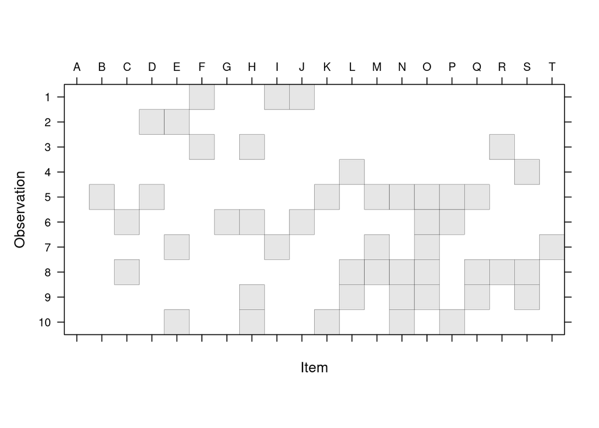

```r
image(Matrix(W1),ylim=c(1,10),sub="",ylab="Observation",
      xlab="Item",
      ## draw tick labels at top
      scales=list(at=1:20,x=list(labels=colnames(W1),
                                 alternating=2)))
```

Since we chose which items/individuals to include for each observation randomly and independently (Bernoulli with probability 0.25), we have a highly variable number of individuals present for different observations (1-11). This would be realistic for some examples (authorship), unrealistic for others (hockey) … I don’t think it really makes much difference computationally (statistically, having some observations with a single member must make estimation more powerful …) The 0/1 matrix (indicator variable for whether item $i$ is included in observation $j$) is convenient, and will turn out to be the form we need for inclusion in the model. It should be fairly straightforward to convert other forms (e.g. a list of sets of items associated with each observation) to this form …

Now simulate the response variable.

```r
b <- rnorm(nm)  ## item-level effects
beta <- c(1,2)
M <- data.frame(x=runif(nobs0))
X <- model.matrix(~x, data=M)
## n.b. get in trouble if we don't add residual error
## (theta is scaled relative to residual error)
## here, use theta=sigma=1
M$y <- c(X %*% beta) + c(W1 %*% b) +rnorm(nobs0,sd=1)
## we'll need this later
M$fake <- rep(LETTERS[seq(nm)],length.out=nobs0)
```

## modular/from scratch in lme4

Fit (see `?modular`):

```r
## helpful to specify a factor with the right levels:
## actual values are unimportant since we will specify Zt/Ztlist directly
lmod <- lFormula(y~x+(1|fake), data=M)
lmod$reTrms$Zt <- lmod$reTrms$Ztlist[[1]] <- Matrix(t(W1))
devfun <- do.call(mkLmerDevfun, lmod)
opt <- optimizeLmer(devfun)
m1 <- mkMerMod(environment(devfun), opt, lmod$reTrms, fr = lmod$fr)
```

Results look OK (correct fixed effects, item and residual variance estimated):

```r
m1
```

```
## Linear mixed model fit by REML ['lmerMod']
## REML criterion at convergence: 1506.767
## Random effects:
##  Groups   Name        Std.Dev.
##  fake     (Intercept) 0.9580
##  Residual             0.9944
## Number of obs: 500, groups:  fake, 20
## Fixed Effects:
## (Intercept)            x
##      0.8534       2.2106
```

The conditional modes by item look good:

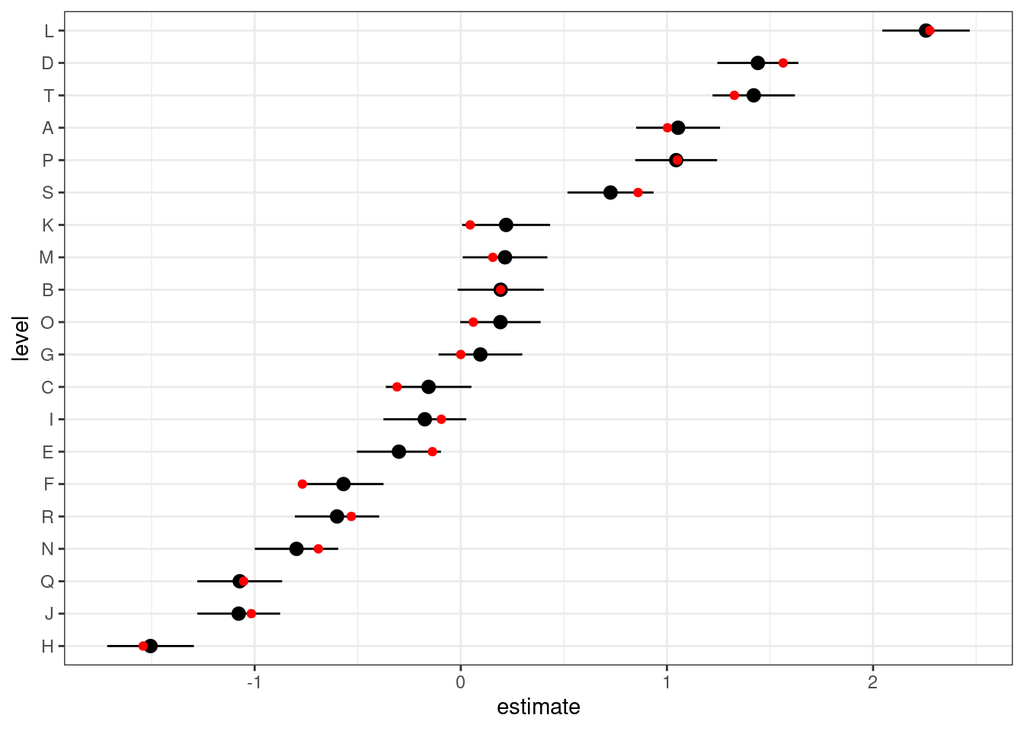

```r
dd <- tidy(m1, effects="ran_vals")
dd <- transform(dd, level=reorder(level,estimate))
truth <- data.frame(level=LETTERS[seq(nm)],estimate=b)
ggplot(dd,aes(x=level,y=estimate))+
    geom_pointrange(aes(ymin=estimate-2*std.error,
              ymax=estimate+2*std.error))+coord_flip()+
    geom_point(data=truth,colour="red")
```

## see also

```r
sos::findFn("{multiple membership}") ## GPvam, R2MLwiN, RealVAMS, ...
```

- `r-sig-mixed-models` posts ([here](https://stat.ethz.ch/pipermail/r-sig-mixed-models/2012q1/017826.html), [here](https://stat.ethz.ch/pipermail/r-sig-mixed-models/2011q2/006318.html))
- `mm()`, `mmc()` in the `brms` package
- `mult.memb()` in the `MCMCglmm()` package

## function encapsulation

Suppose we have a real data frame `M` and a (sparse) weight matrix `W` (or? a list `L` of weight vectors?

```r
##' @param formula mixed model formula
##' @param data data frame (possibly but not necessarily containing factors
##' @param memb_mat list of weights matrices  with which to replace Zt components
lmer_multimemb <- function(formula,data,memb_mat=list(),...) {
  ## FIXME: pass ... through appropriately
  ## FIXME: test dimensions
  mnms <- names(memb_mat)
  fb <- findbars(formula)
  gvars <- vapply(fb, function(x) deparse(x[[3]]), character(1))
  Ztlist <- list()
  for (i in seq_along(fb)) {
    fbnm <- deparse(fb[[i]])
    ## find corresponding random-effects term
    w <- which(mnms==gvars[i])
    if (length(w)>0) {
      M <- Matrix::Matrix(memb_mat[[w]])
      ## extract LHS (effect)
      form <- as.formula(substitute(~z,list(z=fb[[i]][[2]])))
      ## construct model matrix & compute Khatri-Rao product
      X <- model.matrix(form,data=data)
      Zt <- Matrix::KhatriRao(t(M), t(X), make.dimnames=TRUE)
      ## FIXME: mess with names?
      Ztlist[[fbnm]] <- Zt
      ## if necessary, add factor to data
      if (!gvars[[i]] %in% names(data)) {
        ## if the factor has non-trivial ordering, it should be included
        ## in the data.  Do we have to worry about ordering of Z? test!
        data[[gvars[i]]] <- factor(colnames(memb_mat[[w]]))
      }
    } ## if  (length(w)>0)
  } ## for i in seq(fb)
  ## call lFormula  (FIXME: allow glFormula)
  lmod <- lFormula(formula,data=data)
  ## substitute new Ztlist elements
  for (m in names(Ztlist)) {
    lmod$reTrms$Ztlist[[m]] <- Ztlist[[m]]
  }
  lmod$reTrms$Zt <- do.call(rbind,lmod$reTrms$Ztlist)
  ## finish fitting
  devfun <- do.call(mkLmerDevfun, lmod)
  opt <- optimizeLmer(devfun)
  m1 <- mkMerMod(environment(devfun), opt, lmod$reTrms, fr = lmod$fr)
  return(m1)
}
```

This seems to work …

```r
(m2 <- lmer_multimemb(formula=y ~ x + (1|team),
               data=M,
               memb_mat=list(team=W1)))
```

```
## Linear mixed model fit by REML ['lmerMod']
## REML criterion at convergence: 1506.767
## Random effects:
##  Groups   Name        Std.Dev.
##  team     (Intercept) 0.9580
##  Residual             0.9944
## Number of obs: 500, groups:  team, 20
## Fixed Effects:
## (Intercept)            x
##      0.8534       2.2106
```

## Data formats

We want to allow users to conveniently transform whatever data formats they have to a sparse incidence matrix.

### memberships in multiple columns

Maybe it’s in multiple columns (as in this example from Harold Doran):

```r
tmp <- data.frame(id = 1:5,
                  tch1 = c(10,10,11,11,12),
                  tch2 = c(77,15,NA,10,11),
                  tch3 = c(NA, NA, 77, 12, 10),
                  y = rnorm(5), x = rnorm(5))
## list of teachers
all_tch <- with(tmp,sort(unique(na.omit(c(tch1,tch2,tch3)))))
## empty (sparse) matrix with dimnames
W2 <- Matrix(0,nrow=nrow(tmp),ncol=length(all_tch),
            dimnames=list(as.character(tmp$id),as.character(all_tch)))
## melt all teacher columns to long/combined format
all_prs0 <- na.omit(reshape2::melt(tmp[,1:4],id="id"))
all_prs1 <- all_prs0[,c("id","value")]
## convert to numeric indices
all_prs2 <- all_prs1
all_prs2[] <- lapply(all_prs2,function(x) as.numeric(factor(x)))
## convert to two-column matrix
all_prs2 <- as.matrix(all_prs2)
W2[all_prs2] <- 1 ## weights
```

## row_ID, col_ID, weight as three columns

As pointed out by Robyn Wimmers, `reshape2::dcast` is handy if your data are in a three-column format (row_label, col_label, weight). It’s marginally less efficient because it initially generates a dense matrix.

```r
## convert from the format we have above
all_prs3 <- all_prs1
all_prs3[] <- lapply(all_prs3, factor)
all_prs3$wts <- 1
## now data frame -> matrix
W3 <- reshape2::dcast(all_prs3,id~value, value.var="wts", fill=0)
idvars <- W3$id
W <- Matrix(as.matrix(W3[,-1])) ## drop 'id' column and sparsify
rownames(W3) <- as.character(idvars)
```

# glmmTMB

Can we do this with `glmmTMB`?

(need `modular` branch for now: `remotes::install_github("glmmTMB/glmmTMB/glmmTMB@modular")`)

```r
library(glmmTMB)
gt0 <- glmmTMB(y~x+(1|fake), data=M, doFit = FALSE)
gt1 <- fitTMB(gt0, doOptim = FALSE)
## now hack data
gt1$env$data$Z <- as(Matrix(W1), "TsparseMatrix")
## rebuild TMB object
gt1 <- with(gt1$env,
                TMB::MakeADFun(data,
                               parameters,
                               map = map,
                               random = random,
                               silent = silent,
                               DLL = "glmmTMB"))
fit <- with(gt1, nlminb(par, objective = fn, gr = gr))
m3 <- finalizeTMB(gt0, gt1, fit)
```

```r
L1 <- (list(raw_lme4 = m1, multimemb = m2, glmmTMB = m3)
    |> purrr::map_dfr(tidy, effects = "fixed", .id = "model")
    |> select(model, term, estimate, std.error)
)
(L1 |> select(-std.error)
    |> pivot_wider(id_cols = "term", names_from = "model",
                   values_from = "estimate")
)
```

```
## # A tibble: 2 × 4
##   term        raw_lme4 multimemb glmmTMB
##   <chr>          <dbl>     <dbl>   <dbl>
## 1 (Intercept)    0.853     0.853   0.853
## 2 x              2.21      2.21    2.21
```

```r
(L1 |> select(-estimate)
    |> pivot_wider(id_cols = "term", names_from = "model",
                   values_from = "std.error")
)
```

```
## # A tibble: 2 × 4
##   term        raw_lme4 multimemb glmmTMB
##   <chr>          <dbl>     <dbl>   <dbl>
## 1 (Intercept)    0.146     0.146   0.145
## 2 x              0.158     0.158   0.158
```

## from package

JP van Paridon and Phillip Alday have a package on GitHub that provides methods to fit these kinds of problems. Don’t quite know how to adapt to this example at the moment …

```r
## NOT WORKING YET
## slightly naughty
while (!require("lmerMultiMember")) {
    remotes::install_github("https://github.com/jvparidon/lmerMultiMember")
}
m0 <- lmerMultiMember::lmer(y~x+(1|fake), memberships = list(fake = W1), data=M)
## subscript too long ..
```

[output not shown]